Open camera or QR reader and

scan code to access this article

and other resources online.

[figure not shown]

REVIEW

Photobiomodulation in Acute Traumatic Brain Injury:

A Systematic Review and Meta-Analysis

Andrew Robert Stevens,<sup>1–3,</sup>*Mohammed Hadis,<sup>3</sup>Michael Milward,<sup>3</sup>Zubair Ahmed,<sup>1,2,4</sup>

Antonio Belli,<sup>1,2,4</sup>William Palin,<sup>3</sup>and David James Davies<sup>1–4</sup>

Abstract

Photobiomodulation (PBM) is a therapeutic modality that has gained increasing interest in neuroscience

applications, including acute traumatic brain injury (TBI). Its proposed mechanisms for therapeutic effect

when delivered to the injured brain include antiapoptotic and anti-inﬂammatory effects. This systematic

review summarizes the available evidence for the value of PBM in improving outcomes in acute TBI and

presents a meta-analysis of the pre-clinical evidence for neurological severity score (NSS) and lesion size

in animal models of TBI. A systematic review of the literature was performed, with searches and data extrac-

tion performed independently in duplicate by two authors. Eighteen published articles were identiﬁed for

inclusion: seventeen pre-clinical studies of in vivo animal models and one clinical study in human patients.

The available human study supports safety and feasibility of PBM in acute moderate TBI. For pre-clinical

studies, meta-analysis for NSS and lesion size were found to favor intervention versus control. Subgroup

analysis based on PBM parameter variables for these outcomes was performed. Favorable parameters

were identiﬁed as: wavelengths in the region of 665 nm and 810 nm; time to ﬁrst administration of PBM

£4 h; total number of daily treatments £3. No differences were identiﬁed between pulsed and continuous

wave modes or energy delivery. Mechanistic substudies within included in vivo studies are presented and

were found to support hypotheses of antiapoptotic, anti-inﬂammatory, and pro-proliferative effects, and a

modulation of cellular metabolism. This systematic review provides substantial meta-analysis evidence of

the beneﬁts of PBM on functional and histological outcomes of TBI in in vivo mammalian models. Study

design and PBM parameters should be closely considered for future human clinical studies.

Keywords: low-level light therapy; meta-analysis; systematic review; photobiomodulation; therapeutics;

traumatic brain injury

Introduction

Traumatic brain injury (TBI) is a global health problem

and a signiﬁcant cause of death and life-long disabil-

ity. Worldwide, annual incidence of TBI is estimated at

more than 50 million,<sup>1,2</sup>with annual costs to the global

economy approximately US$400 billion.<sup>1</sup>No effective

disease-modifying therapy has been identiﬁed to control

the variety of post-injury responses and prevent second-

ary injury to brain tissue and cell damage/loss.<sup>3</sup>

These pathophysiological mechanisms include the

well-established factors such as raised intracranial pres-

sure (ICP) and cerebral hypoxia, and current therapeutic

1Department of Neuroscience and Ophthalmology, Institute of Inﬂammation and Ageing, and 4Centre for Trauma Sciences Research, University of Birmingham, Edgbaston,

Birmingham, United Kingdom.

2NIHR Surgical Reconstruction and Microbiology Research Centre, University Hospitals Birmingham, Birmingham, United Kingdom.

3Phototherapy Research Group, School of Dentistry, University of Birmingham, Birmingham, United Kingdom.

*Address correspondence to: Mr. Andrew R. Stevens, <sup>1</sup>Department of Neuroscience and Ophthalmology, Institute of Inﬂammation and Ageing, University of Birmingham,

Edgbaston, Birmingham, B15 2TT, United Kingdom, E-mail: a.stevens@bham.ac.uk

Journal of Neurotrauma

39:1–18 (XXXX 00, 2022)

ª Mary Ann Liebert, Inc.

DOI: 10.1089/neu.2022.0140

1

paradigms are centered on monitoring and maintaining

intracranial homeostasis, principally with respect to pres-

sure and oxygenation.<sup>4</sup>Other pathways of injury are

gaining increasing recognition, however: mitochondrial

dysfunction,<sup>5</sup>neuroinﬂammation,<sup>6</sup>excitotoxicity,<sup>7</sup>and

oxidative stress.<sup>8</sup>

Pharmacological therapeutics typically target discrete

pathways or mechanisms, but have thus far failed to dem-

onstrate clear beneﬁt in the context of this multi-faceted

pathology.<sup>9</sup>Trialing of multiple novel therapies in a clin-

ical setting is challenging without stepwise integration of

single novel therapies into standard of care, which indi-

vidually may not surpass the threshold for detectable

therapeutic beneﬁt. Single therapies that are able to target

multiple mechanisms within the pathophysiological path-

way therefore hold considerable therapeutic potential.

Photobiomodulation (PBM) is the application of red/

near-infrared (R/NIR) light (600–1100 nm) to biologi-

cal tissue for the purpose of therapeutic advantage, resto-

ration of function, or enhancement of physiology.<sup>10</sup>The

concept of the biological effect of photons from across

the electromagnetic (EM) spectrum is well established.

Photons with low wavelength and high energy (gamma

rays) are administered as radiotherapy, and photons in

the ultraviolet part (UVB) of the EM spectrum are inte-

gral in the biological synthesis of cholecalciferol. The

use of 5-aminolavulanic acid, preferentially taken up by

high-grade glioma tissue and converted to protoporphy-

rin IX that ﬂuoresces under violet-blue (405 nm) light,

has become central in oncological neurosurgery to max-

imize resection margins.<sup>11</sup>PBM is similarly based on

a photobiological interaction of longer, lower energy

photons.

Although the mechanism of PBM is not fully es-

tablished,<sup>12,13</sup>cytochrome c oxidase (CCO), the terminal

component of the electron transport chain, is thought to

be the principle chromophore of absorption of R/NIR

light.<sup>14</sup>Absorption of R/NIR photons by CCO is thought

to lead to downstream modulation of reactive oxygen

species production via effects on mitochondrial membrane

potential (MMP), an increase in nitric oxide dissociation,

and raised adenosine triphosphate (ATP) production.<sup>15</sup>

PBM is additionally proposed to potentiate light-

sensitive ion channels,<sup>16</sup>resulting in increased intracel-

lular calcium concentrations, in turn affecting levels of

cyclic adenosine monophosphate and modulation of

downstream transcription factors. Together, these mo-

lecular interactions are proposed to lead to the various

reported effects (antiapoptotic, anti-inﬂammatory, pro-

proliferative<sup>12–15</sup>).

The application of R/NIR light, because of its high

scatter and absorbance in biological tissue resulting in at-

tenuated tissue irradiance at depth, lends itself more read-

ily to topical application for externally accessible tissues.

The scientiﬁc and clinical interest in such contexts has a

broad evidence base, particularly in: dermatological

pathology,<sup>17</sup>burns,<sup>18</sup>wound healing,<sup>15</sup>cancer-related lym-

phedema,<sup>19</sup>and oral inﬂammatory conditions.<sup>20</sup>After

these successes, attention to the targeting of R/NIR light

at deeper biological tissues has since increased in recent

years,<sup>21–24</sup>including the central nervous system.<sup>25–29</sup>

The application of PBM in the ﬁeld of TBI has gath-

ered interest and scientiﬁc evidence in the last decade.

The application of PBM as a therapeutic intervention

for the injured brain has taken two principle forms: (1)

in the acute setting post-injury, intended as a neuropro-

tective/neurorestorative therapy; and (2) in the rehabili-

tative setting in the chronic phase post-injury, for the

purpose of improving symptomatology or neurocognitive/

neuropsychological function.

Pre-clinical studies on the efﬁcacy of PBM in acute

TBI have generated positive results, utilizing moderate

or severe models of TBI in rodent species,<sup>30</sup>with prom-

ising results in an early clinical study.<sup>31</sup>The methodol-

ogy, outcome measures, and hypothesized mechanisms

in chronic contexts differ greatly from acute applications,

and as such, the chronic/rehabilitative phase of TBI re-

covery is beyond the scope of this review.

The efﬁcacy of PBM in ischemic stroke had also

been considered promising.<sup>32</sup>Such promise culminated

in a phase III randomized controlled trial—the NEST-3

study,<sup>33</sup>which did not demonstrate efﬁcacy and was ter-

minated early. The study design, however, has stimulated

criticism,<sup>34</sup>the themes of which represent ongoing scien-

tiﬁc ‘‘unknowns’’ in PBM research. The optimal vari-

ables of dosing are yet to be established, including

irradiance (both surface and after tissue penetration),

time of initiation post-injury, optimal duration of thera-

peutic course, and optimal brain regions for irradiance.

Formally establishing the evidence base in TBI is

essential for informing future directions in both pre-

clinical, translational, and clinical research, to minimize

the risk of future clinical PBM studies in TBI using sub-

optimal parameters.

Aims

This systematic review and meta-analysis seeks to com-

prehensively identify and summarize the scientiﬁc litera-

ture on the use of PBM in acute TBI. The variables of

PBM implemented in identiﬁed studies will be analyzed

with respect to the observed outcomes.

Methods

A systematic review of the literature was performed

on October 4, 2021 following the methodology of the

Cochrane Handbook for Systematic Reviews and pre-

sented in accordance with the Preferred Reporting

Items for Systematic Reviews and Meta-analyses

(PRISMA).<sup>35</sup>

2

STEVENS ET AL.

Systematic searches were performed independently in

duplicate. The following databases were searched, from

their respective inception to October 4<sup>,</sup>2021: Medline,

Embase, Cochrane Central, Scopus, Google Scholar,

and Web of Science. Reference lists of pertinent articles

on the topic were hand-searched for suitable articles.

Reference lists of identiﬁed articles for inclusion were

also hand-searched for suitable articles. An example

search strategy for Medline is given below:

Search:

1. Exp Low-Level Light Therapy (LLLT)

2. Photobiomodulation.mp

3. Exp Phototherapy/

4. Phototherapy.mp

5. Low level laser therapy.mp

6. 1 or 2 or 3 or 4 or 5

7. Exp Brain Injuries, Traumatic/

8. Exp Craniocerebral Trauma/

9. Head injury.mp

10. 7 or 8 or 9

11. 6 and 10

Study selection

Studies were independently screened for inclusion by two

reviewers (A.R.S., and Z.A.). Initial screening based on

title and abstract were performed, followed by full text

screening. Eligibility for study inclusion was deﬁned

as: use of PBM therapy (R/NIR) in acute TBI. Any meth-

odology was accepted, and studies involving in vitro/

in vivo animal or human subjects were included. Studies

that only reported computational modeling methods were

excluded. Articles were excluded where blue or white

light therapy was used, and where PBM was used in

the chronic or rehabilitative phase of injury.

Conference abstracts were excluded to avoid duplicate

reporting where insufﬁcient detail was available in ab-

stracts to identify such cases; where full manuscripts

were available for conference proceedings, these were

screened against included manuscripts to exclude dupli-

cate reporting.

Data extraction

Data were extracted from included reports using a piloted

form. Data extracted from pre-clinical studies included:

species and injury model used, number of replicates,

PBM therapy variables (wavelength, irradiance, timing,

doses, light source, delivery site), outcomes, and ﬁndings

of any mechanistic substudies. Data were extracted for

meta-analysis for neurological severity score and lesion

size indices, and other functional and histological out-

comes were extracted for narrative presentation. Where

data were not directly reported as values, values were ex-

trapolated from published ﬁgures. From clinical studies,

patient characteristics, PBM therapy variables, any com-

parator used, outcome measures, and outcomes were

recorded.

Synthesis of results

This systematic review presents a combination of meta-

analysis and narrative presentation of available data.

Speciﬁc outcome measures were deemed suitable for

meta-analysis where ‡ n = 3 studies had presented data

(either directly or suitable for accurate extrapolation) in

this regard. Remaining outcomes reported in included

articles will be presented in tabular and narrative form

without statistical analysis.

Risk of bias

Risk of bias in individual studies was assessed using the

SYRCLE tool for assessing risk of bias,<sup>36</sup>and overall risk

of bias was determined as low, moderate, or high for each

included article. For clinical trials, Cochrane Risk of Bias

tool<sup>37</sup>with overall risk of bias determined via design

quality assessment as good, fair, or poor for each in-

cluded article.

Statistical analysis

Data for meta-analysis were extracted as mean, standard

deviation (SD), and n number. Where standard error of

the mean (SEM) was presented, SD was calculated using

SEM and n number. Review Manager 5.4.1 (Cochrane

Collaboration, 2022) was used for meta-analysis. Effect

size was calculated with a 95% conﬁdence interval,

using a standardized mean difference model because of

heterogenous data reporting. A ﬁxed effects model was

used, and where heterogeneity was calculated by chi-

square test as ‡50%, a random effects model was used.

Results

The search strategy identiﬁed 1784 records, with 1459

remaining after removal of duplicates, leaving 93 full-

text articles that were assessed for eligibility against

the inclusion/exclusion criteria after abstract screening.

Eighteen studies met the criteria for inclusion, with 17

pre-clinical studies being conducted in animal mod-

els<sup>38–54</sup>and one clinical study using human partici-

pants.<sup>31</sup>The full ﬂowchart for search results is shown

in the PRISMA diagram in Figure 1.

Human studies

We identiﬁed a single study of PBM in acute TBI in

human participants. Figuero Longo and associates (2020)<sup>31</sup>

randomized 68 patients with moderate TBI to receive ei-

ther sham therapy or transcranial PBM within 72 h of in-

jury. The PBM therapy application used an 810 nm light-

emitting diode (LED) array within a custom helmet, with

reported average irradiance to the scalp of 36 mW/cm<sup>2</sup>for

PHOTOBIOMODULATION IN ACUTE TBI

3

20 min applications. The authors calculated that their sys-

tem provides a surface energy of 1.3 J/cm<sup>2</sup>per session

based

on

cadaveric

modeling.

Patients

received

3 · 20 min sessions, at least 12 h apart. Twenty-eight pa-

tients received at least one PBM session and were evalu-

ated for diffusion magnetic resonance imaging outcomes

and Rivermead post-concussion questionnaire (RPQ) in

comparison with the control group.

There were signiﬁcant changes in radial diffusivity,

mean diffusivity, and fractional anisotropy at the late sub-

acute stage between PBM and sham groups, although not

for axial diffusivity or other time points. The RPQ scores

were somewhat improved in the PBM group versus sham,

although not of statistical signiﬁcance; it is noteworthy

that the study is not appropriately powered to identify sig-

niﬁcance for functional outcomes.

Animal studies

We identiﬁed 17 studies of PBM in animal models of

TBI<sup>38–54</sup>(Table 1). All studies used an in vivo model of

TBI, with one study using neuronal cell cultures as an

additional model.<sup>39</sup>Four studies used rats,<sup>45,47,48,52</sup>one

study used a transgenic (X-1 knock-out) mouse,<sup>46</sup>and

six used weight drop (WD)<sup>40,50,51,53,54</sup>(one in a repeated

TBI model<sup>45</sup>), two used controlled scalp impact,<sup>39,46</sup>

one open lateral ﬂuid percussion (LFP),<sup>48</sup>and one

blast-induced neurotrauma (BINT).<sup>47</sup>

The available reported PBM variables for therapeutic

regimens are given in Table 1, with all used permutations

of a variable given (where a study has used multiple ther-

apeutic regimens). Notably, 15 studies used a wavelength

in the 800–810 nm region, either alone or in comparison

with another wavelength, with two studies not using

a wavelength in this region<sup>48,52</sup>(using 670 or 830 nm).

Full width half of maximum values were not reported.

Two studies used a LED,<sup>48,52</sup>15 employing a laser

source.

Two studies delivered PBM directly to the cortical sur-

face of the lesion site<sup>49,53</sup>with 15 studies applying the

source to skull or scalp. Four studies used a pulsed

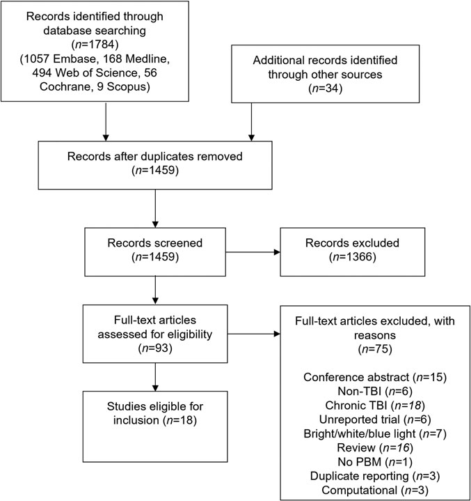

FIG. 1.

Preferred Reporting Items for Systematic Reviews and Meta-analyses ﬂow chart of systematic

review process.

4

STEVENS ET AL.

Table 1. Summary Table of Included Studies

Species

TBI Model

Severity

Wavelength

(nm)

Site of

administration

Mode

Laser/

LED

Average

irradiance

(mW/cm2)

Cortical

irradiance

(mW/cm2)

Exposure

time

(min)

Energy

(J/cm2)

per dose

Cortical

surface

energy

(J/cm2)

per dose

First dose

post-

injury (h)

Total

doses

(regime)

Ando et al.,

201138

Mouse

CCI

Severe

810

Scalp (over

craniotomy)

CW, 10 Hz,

100 Hz

Laser

50

3-7.5

12

36

4

1

Dong et al.,

201539

Mouse

Scalp

impact

Moderate

810

Scalp

10 Hz

Laser

150

8.9

4

36

1.8 to 2.5

4

1

Esenaliev

et al., 201847

Rat

Closed

BINT

Mild to

moderate

808

Scalp

NPLT (20Hz)

Laser

5

300

1

1

Giacci et al.,

201448

Rat

Open LFP

Mild

670, 830

Scalp (over

craniotomy)

CW

LED

30

28.4 / 22.5

0

7 (OD)

Khuman et al.,

201249

Mouse

CCI

Not stated

800

Cortex or

scalp over

craniotomy

CW

Laser

250, 500,

1000

*, 250, 500,

1000

2, 7

30, 60, 105,

120, 210

*, 30, 60, 105,

120, 210

1 or 4

1

Oron et al.,

200750

Mouse

Skull WD

Mild

808

Skull

CW

Laser

10 or 20

2

1.2-2.4 J/cm2

4

1

Oron et al.,

201251

Mouse

Skull WD

Mild to

moderate

808

Skull

CW, 100 Hz,

600 Hz

Laser

21

10

2

2.52

1.2

4, 6 or 8

1

Quirk et al.,

201252

Rat

CCI

Moderate

670

Scalp (over

craniotomy)

CW

LED

50

5

15

Not stated

6 or 20 (BD)

Shemesh

et al., 202253

Mouse

Scalp WD

Severe

810

Cortex

CW

Laser

50

50

15

45

45

0.16

1

Wu et al.,

201054

Mouse

Skull WD

Moderate

to severe

660, 810, 980

Scalp

CW

Laser

150

4

36

4

1

Wu et al.,

201240

Mouse

Skull WD

Moderate

to severe

665, 730,

810, 980

Scalp

CW

Laser

150

4

36

4

1

Xuan et al.,

201341

Mouse

CCI

Severe

810

Scalp (over

craniotomy)

CW

Laser

25

12

18

4

1/3/14 (OD)

Xuan et al.,

201443

Mouse

CCI

Moderate

to severe

810

Scalp (over

craniotomy)

CW

Laser

25

12

18

4

1/3 (OD)

Xuan et al.,

201542

Mouse

CCI

Severe

810

Scalp (over

craniotomy)

CW

Laser

50

12

36

4

1/3 (OD)

Xuan et al.,

201644

Mouse

CCI

Severe

810

Scalp (over

craniotomy)

CW

Laser

25

12

18

4

3/14 (OD)

Yang et al.,

202045

Rat

Skull WD

(repeated)

Mild

808

Scalp

CW

Laser

350

25

2

2

15 (OD)

Zhang et al.,

201446

Mouse

(X-1 KO)

Scalp

impact

Mild

810

Scalp

10 Hz

Laser

150

Not stated

4

36

1.8-2.5

4

1

TBI, traumatic brain injury; LED, light-emitting diode; CCI, controlled cortical impact; CW, continuous wave; BINT, blast-induced neurotrauma; NPLT, nano-pulsed laser therapy; LFP, lateral ﬂuid percussion; WD, weight

drop; BD, twice a day; OD, once a day.

*denotes where a protocol has been used but irradiance parameters have not been presented.

5

wave (PW) source,<sup>38,39,46,51</sup>alone or on combination

with continuous wave (CW), one used nano-pulsed

laser therapy (NPLT)<sup>47</sup>, and 12 used CW alone. One

study used PBM in combination with metabolic sub-

strates,<sup>39</sup>16 using PBM alone. All studies commenced

PBM within 8 h of injury. Ten studies used PBM proto-

cols with a single dose of PBM,<sup>38–40,46–48,50,51,53,54</sup>with

seven using alternative and additional course durations

up to 15 days.<sup>45</sup>

Meta-analysis

Two outcomes were sufﬁciently reported in the included

studies to permit robust meta-analysis: neurological

severity score (NSS) and lesion size. The NSS was pre-

dominantly reported as baseline NSS (– SD/SEM) and

end-point NSS (– SD/SEM). Insufﬁcient detail was avail-

able in any included study, or in the wider literature, to

calculate or infer the DSD, and so the end-point NSS

was used in a standardized mean difference model.

NSS.

the frequent use of substudy groups based on varying

(Fig. 2). Overall, effect size is -1.55 (-2.10, -1.01) in

favor of PBM versus control ( p < 0.00001, I<sup>2</sup>82%).

Given the heterogeneity of therapeutic regimens

employed, both inter- and intra- article, subgroup analy-

sis was performed based on distinct variables: CW versus

PW, wavelength of PBM, timing of ﬁrst dose post-injury,

total number of doses, and incident energy per dose (cal-

culated for cortical surface energy). Both continuous and

pulsed wave PBM have statistically signiﬁcant effects on

NSS.

Ando and colleagues (2011)<sup>38</sup>reported statistically

signiﬁcant advantage of PW at 10 Hz over CW, but not

of PW at 100 Hz. Wavelengths in the region of 665/

810 nm are associated with positive effects, but not

730/980 nm. A ﬁrst dose after 4 h post-injury or a course

of treatment with more than three doses were not effec-

tive, and all energy values were associated with reduced

NSS. Dosing regimens for substudies and therapeutic

protocols included in the meta-analysis are described in

Table 2 and subgroup analysis in Table 3.

Lesion size.

(-2.19, -0.95) ( p < 0.00001, I<sup>2</sup>= 75%). Standardized mean

difference was used because of heterogeneity in reported

effect and measurement techniques. Forest plot for lesion

size across included studies is illustrated in Figure 3. Dos-

ing regimens for substudies and therapeutic protocols in-

cluded in the meta-analysis are described in Table 2.

Alternative functional outcomes

Morris Water Maze (MWM) was an outcome measure

used in n = 5 studies.<sup>39,43,44,47,49</sup>There was signiﬁcant

heterogeneity, however, between training schedules, tim-

ing of testing post-injury (varying from seven to 55 days

post-injury), the use of hidden platform, visible platform,

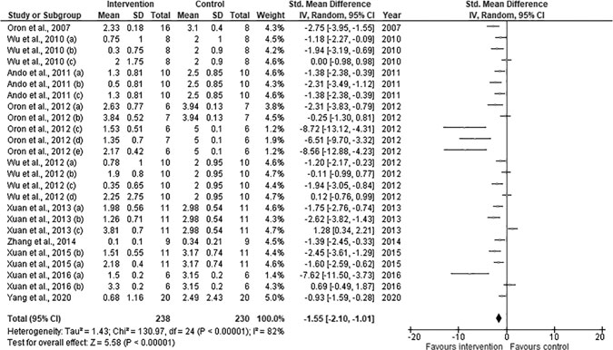

FIG. 2.

Forest plot of end neurological severity score (standardized mean difference). Neurological esverity

score at 28 days with exception of Yang and associates (2020), Zhang and colleagues (2014)<sup>46</sup>(both 14

conditions compared with single control group. SD, standard deviation; CI, conﬁdence interval.

6

STEVENS ET AL.

Table 2. Dosing Regimens of Studies and Substudies Included in Meta-Analyses

f

k (nm)

Average

irradiance

(mW/cm2)

Average

Irradiance

(cortex) (mW/cm2)

Exposure

time (min)

Administration

First dose

post-injury (h)

Doses

Brief results of intervention versus

control (p value where available)

Oron et al., 200750

CW

808

10 or 20

0.899

2

Skull

4

1

Improved NSS at 28 days ( p < 0.05)

Wu et al., 2010 (a)54

CW

665

150

4

Scalp*

4

1

Improved NSS at all time points to 28 days ( p < 0.05)

and lesion size ( p < 0.05)

Wu et al., 2010 (b)54

CW

810

150

9.39

4

Scalp*

4

1

Improved NSS at all time points to 28 days ( p < 0.05)

and lesion size ( p < 0.01)

Wu et al., 2010 (c)54

CW

980

150

9.39

4

Scalp*

4

1

No effect on NSS at 28 days

Ando et al., 2011 (a)

CW

810

50

5.25

12

Scalp*

4

1

Moderately effective for improvement of NSS at 28

days

Ando et al., 2011 (b)

10 Hz

810

50

5.25

12

Scalp*

4

1

Most effective for improvement of NSS at 28 days

( p < 0.001), and brain lesion volume ( p < 0.01)

Ando et al., 2011 (c)

100 Hz

810

50

5.25

12

Scalp*

4

1

Moderately effective for improvement of NSS at 28

days

Khuman et al., 2012 (a)49

CW

800

500

0.5

2

Cortex

1

1

No effect on lesion size at 14 days ( p = 0.12)

Oron et al., 2012 (a)51

CW

808

21

10

2

Skull

6

1

Effective for improvement of NSS at 28 and 56 days

( p < 0.05)

Oron et al., 2012 (b)51

CW

808

21

10

2

Skull

8

1

No effect on NSS at 56 days

Oron et al., 2012 (c)51

CW

808

21

10

2

Skull

4

1

Effective for improvement of NSS at 56 days

( p < 0.001), and brain lesion volume ( p < 0.01)

Oron et al., 2012 (d)51

100 Hz

808

21

10

2

Skull

4

1

Effective for improvement of NSS at 56 days

( p < 0.001), and brain lesion volume ( p < 0.01)

Oron et al., 2012 (e)51

600 Hz

808

21

10

2

Skull

4

1

Effective for improvement of NSS at 56 days

( p < 0.001)

Wu et al., 2012 (a)40

CW

665

150

*9.39

4

Scalp

4

1

Effective for improvement of NSS at 28 days ( p < 0.05)

Wu et al., 2012 (b)40

CW

730

150

*9.39

4

Scalp

4

1

No effect on NSS at 28 days

Wu et al., 2012 (c)40

CW

810

150

9.39

4

Scalp

4

1

Effective for improvement of NSS at 28 days

( p < 0.001)

Wu et al., 2012 (d)40

CW

980

150

9.39

4

Scalp

4

1

No effect on NSS at 28 days

Xuan et al., 2013 (a)41

CW

810

25

2.63

12

Scalp*

4

1

No effect on NSS or lesion size at 28 days

Xuan et al., 2013 (b)41

CW

810

25

2.63

12

Scalp*

4

3

Effective for improvement of NSS at 28 days

( p < 0.001) and lesion size ( p < 0.01)

Xuan et al., 2013 (c)41

CW

810

25

2.63

12

Scalp*

4

14

Effective for improvement lesion size at 28 days

( p < 0.01)

Giacci et al., 2014 (a)48

CW

670

0.02

*<1

30

Scalp*

0

7

No effect on lesion size at 7 days

Giacci et al., 2014 (b)48

CW

830

0.01

*<1

30

Scalp*

0

7

No effect on lesion size at 7 days

Xuan et al., 2015 (a)42

CW

810

50

3.13

12

Scalp*

4

1

Effective for improvement of NSS at 28 days ( p < 0.05)

Xuan et al., 2015 (b)42

CW

810

50

3.13

12

Scalp*

4

3

Effective for improvement of NSS at 28 days

( p < 0.001)

Zhang et al., 201446

10Hz

810

150

8.85

4

Scalp

4

1

NSS at day 7 significantly reduced ( p < 0.001)

Xuan et al., 2016 (a)44

CW

810

25

2.63

12

Scalp*

4

3

Improved NSS versus control and versus 14 day

treatment duration from week 2 to week 8 ( p < 0.001)

post-injury

Xuan et al., 2016 (b)44

CW

810

25

2.63

12

Scalp*

4

14

Improved NSS versus control at week 7 ( p < 0.01) and

week 8 ( p < 0.001) post-injury

Yang et al., 202045

CW

808

350

25

2

Scalp

2

15

Improved NSS throughout protocol ( p < 0.05)

CW, continuous wave; NSS, neurological severity score.

Scalp* denotes scalp route of administration with underlying craniotomy.

#, data not available, cortical irradiance is calculated from available data, or extrapolated from available data using transmittance penetration data (Ando and associates (2011) where k = 800-810 nm).

*data not available and incalculable.

7

and probe trials. As such, these were not deemed suitable

for meta-analysis, and the ﬁndings of individual studies

for MWM will be described in the narrative below. Sim-

ilarly, other functional outcomes were used by studies

with varying frequency: forced swim test (n = 1),<sup>38</sup>tail

suspension test (n = 1),<sup>38</sup>wire grip and motion test

(n = 2),<sup>41,43</sup>rotarod score (n = 1),<sup>48</sup>bilateral asymmetry

test (n = 1),<sup>48</sup>beam balance scores (n = 1),<sup>47</sup>nose poke

tasks (n = 1),<sup>52</sup>open ﬁeld, elevated plus maze, Y maze,

and fear conditioning (all n=1),<sup>45</sup>and are discussed below.

Khuman and coworkers (2012)<sup>49</sup>performed MWM tri-

als, with inclusion of probe trials and analysis of progres-

sive improvement. Statistically signiﬁcant improvements

in outcomes were mixed, although 60 J/cm<sup>2</sup>delivered ei-

ther transcranially or directly for a single administration

demonstrated a statistically signiﬁcant improvement ver-

sus controls in all measured MWM domains. All PBM

groups versus controls exhibited greater progressive im-

provement ( p < 0.0001).

Administered directly, 60, 120, and 210 J/cm<sup>2</sup>but

not 30 or 105 J/cm<sup>2</sup>resulted in MWM hidden platform la-

tency improvements, and 60 and 120 J/cm<sup>2</sup>elicited probe

trial improvements. Single dose transcranial administra-

tion of 60 J/cm<sup>2</sup>resulted in improvements in all MWM

Table 3. Subgroup Analyses for End-Point Neurological Severity Score

Variable (n interventional animals)

Effect size [95% CI]

p

I<sup>2</sup>for heterogeneity (p)

Mode

CW (220)

- 1.31[-1.88, -0.73]

<0.00001

82% (< 0.00001)

PW (42)

-2.94 [-4.48, -1.39]

0.0002

79% (0.0006)

Wavelength

660–670 nm (18)

-1.19 [-1.91, -0.47]

0.001

0% (0.98)

730 nm (10)

-0.11 [-0.99, 0.77]

0.81

800–815 nm (216)

-1.93 [-2.59, -1.26]

<0.00001

83% (< 0.00001)

980 nm (18)

0.06 [-0.59, 0.72]

0.85

0% (0.86)

First dose timing post-injury

£ 4 h (249)

-1.60 [-2.18, -1.02]

<0.00001

83% (< 0.00001)

> 4 h (13)

-1.20 [-3.22, 0.81]

0.24

79% (0.03)

Number of treatments

£3 (217)

-1.81 [-2.36, -1.27]

<0.00001

77% (< 0.00001)

>3 (45)

0.31 [-1.18, 1.80]

0.69

88% (0.0003)

Energy per dose at cortical surface

0 < E £ 1 (J/cm<sup>2</sup>) (16)

-2.75 [-3.95, -1.55]

<0.00001

1 < E £ 2 (J/cm<sup>2</sup>) (101)

-2.77 [-4.33, -1.21]

0.0005

90% (< 0.00001)

2 < E £ 3 (J/cm<sup>2</sup>) (95)

-1.12 [-1.68, -0.55]

0.0001

67% (0.001)

E > 3 (J/cm<sup>2</sup>) (50)

-1.36 [-1.90, -0.83]

<0.00001

26% (< 0.00001)

CI, conﬁdence interval; CW, continuous wave; PW, pulsed wave.

Subgroups stratiﬁed from those in Figure 2 and Table 1. Neurological severity score at 28 days with exception of Yang and associates (2020), Zhang and

*, heterogeneity not applicable because of small sample size. Energy per dose at cortical surface is calculated where not reported by respective study as

described in Table 2 caption.

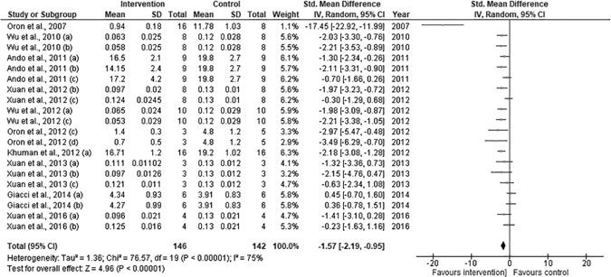

FIG. 3.

Forest plot of lesion size (histologically or radiologically determined). Values at 28 days post-injury

with exception of Oron and associates (2012) (56 days),<sup>51</sup>Khuman and colleagues (2012)<sup>49</sup>(14 days), and

Giacci and coworkers (2014) (7 days). Control total value includes duplicates from varying test conditions

compared with single control group. SD, standard deviation; CI, conﬁdence interval.

8

STEVENS ET AL.

domains if given 1 h after injury, but not after 4 h or daily

for seven days. Esenaliev and colleagues<sup>47</sup>(2018) used

transcranial NPLT in a BINT model. The NPLT was

demonstrated to improve MWM ( p < 0.05) at seven

days post-injury, although this effect was not observed

on subsequent days’ MWM testing.

Xuan and associates (2016)<sup>44</sup>also used the MWM test

at 22 and 49 days post-injury. Groups with TBI receiving

3 · daily PBM treatments at day 22 demonstrated signif-

icant improvements in latency scores for both platform

and probe trials, compared with TBI controls (n = 6,

p < 0.05 and 0.01, respectively). The effect was not sig-

niﬁcant at day 49, although the effect was still observed,

and the group receiving 14 days of treatment had

results similar to TBI controls at both time points

post-injury.

Giacci and coworkers (2014)<sup>48</sup>found no signiﬁcant

differences between control, 670 nm, and 830 nm treat-

ments at seven days post-injury in rotarod score or in

the bilateral asymmetry test contralateral versus ipsilat-

eral latency. Xuan and associates (2013)<sup>41</sup>used a wire

grip and motion test and showed no statistically signiﬁ-

cant improvement in vestibular function in any treatment

group. Xuan and colleagues (2014)<sup>43</sup>utilized the wire

grip and motion test (WGMT) at 7, 14, 21, and 28 days

post-TBI with single or triple doses of PBM (810 nm,

25 mW/cm<sup>2</sup>, 12 min transcranial).

The authors demonstrated statistically signiﬁcant im-

provements in WGMT performance in both single

( p < 0.05) and triple ( p < 0.001) doses at 28 days post-

injury, with signiﬁcant improvements recognized also

at 14 and 21 days in PBM versus control. Khuman and

coworkers (2012)<sup>49</sup>also found no improvement on motor

recovery in a stationary wire grip test.

Esenaliev and associates (2018)<sup>47</sup>used transcranial

NPLT)in a BINT model. The NPLT was demonstrated

to improve beam-balance test scores on day 1 post-injury

( p < 0.01), beam walk test scores on day 1 and 2 post-

injury ( p < 0.001 and <0.05, respectively), not observed

at later time points. Quirk and colleagues (2012)<sup>52</sup>

(670 nm, 50mW/cm<sup>2</sup>, 5 min exposure time, daily expo-

sure for 72h) found some improvements in movement do-

mains (nose poke tasks) though not all, and their

functional testing was limited to this assessment.

Ando and coworkers (2011)<sup>38</sup>found statistically sig-

niﬁcant improvements in the forced swim test (for de-

pression) in the group receiving PW 10 Hz ( p < 0.05) at

28 days post-injury and signiﬁcant improvements in the

tail suspension test for anxiety and depression in both

PW 10 Hz and PW 100 Hz at 28 days post-injury. The

CW groups did not demonstrate statistically signiﬁcant

improvements in these domains. Yang and associates

(2020)<sup>45</sup>performed more extensive functional assess-

ments in their repeated TBI model. Open ﬁeld (mobility),

elevated plus maze (anxiety), Y maze (spatial memory),

and fear conditioning testing all demonstrated statisti-

cally signiﬁcant improvements attributable to PBM ad-

ministration after repeated closed TBI.

Histological outcomes

Wu and associates (2012)<sup>40</sup>marked fractional defects on

morphometric brain sections with hematoxylin and eo-

sin staining and identiﬁed that 665 and 810 nm LLLT

resulted in statistically signiﬁcant reductions in numbers

of mean fractional defect areas ( p < 0.05 and <0.01, re-

spectively, n = 10 per group).

Mechanistic outcomes

Metabolic activity.

Ando and colleagues (2011)<sup>38</sup>per-

formed ATP ﬂuorometric assay for specimens imme-

diately after laser exposure versus control, ﬁnding no

signiﬁcant differences between control and intervention

arms. A trend, however, suggested a mild increase of cor-

tical ATP content with 10 Hz PW treatment, correlating

with this as the treatment condition with greatest effect

on improving NSS and lesion size. Zhang and coworkers

(2014),<sup>46</sup>although principally using W-1 KO mice, per-

formed ATP assay on WT mice with and without LLLT

after mTBI, demonstrating that at 24 h after injury, there

was a signiﬁcant increase in cortical ATP levels with

LLLT ( p < 0.001, n = 6 per group).

Dong and colleagues (2015)<sup>39</sup>included LLLT therapy

to cultured SH-SY5Y neuronal cells in varying condi-

tions. They report that hypoxia (induced by CoCI2) re-

lated cell death was signiﬁcantly reduced by exposure

to 3–10 J/cm<sup>2</sup>LLLT at 2 h post-exposure to hypoxia,

with increasing survival with increasing energy or expo-

sure periods (up to 10 J/cm<sup>2</sup>· 3). The effect was aug-

mented with the addition of mitochondrial substrates to

the media (glucose/lactate/pyruvate). They further dem-

onstrated that this increased survival with LLLT expo-

sure correlated with suppression of lactate level at

0–18 h, increase in ATP level, reduction in reactive oxy-

gen species (ROS) level, and increase in mitochondrial

membrane potential. In an in vivo model of hypoxia

(using cortical topical Oxyrase), they reported complete

prevention of hypoxia related hippocampal tissue loss be-

cause of Oxyrase in the presence of LLLT.

Neuroinﬂammation.

Khuman and coworkers (2012)<sup>49</sup>

performed quantitative analysis of microglial activation.

The 60 J/cm<sup>2</sup>resulted in a signiﬁcant reduction in activated

microglia compared with control treatment (p=0.03, n=4/

group). Khuman and coworkers (2012)<sup>49</sup>also found no

signiﬁcant difference between treatment and control for:

magnitude of brain edema at 24 h, brain tissue loss, or

protein nitrosylation.

Yang and associates (2020)<sup>45</sup>also found that PBM low-

ered microtubule-associated protein 2 (MAP2) dispersion,

PHOTOBIOMODULATION IN ACUTE TBI

9

increased amyloid precursor protein and myelin basic

protein, and reduced cleaved Tau, with the authors con-

cluding that PBM attenuates axonal injury after repeated

TBI. Yang and associates (2020)<sup>45</sup>found that PBM was

associated with attenuated astrogliosis at the lesion site,

and attenuated the increases of ionized calcium binding

adaptor molecule 1 and interleukin (IL)-1B associated

with pro-inﬂammatory shifts post-injury. The PBM associ-

ated elevation of IL-10, in combination with reduction of

IL-1B was attributed by the authors to a shift from ‘‘pro-

inﬂammatory’’ to ‘‘anti-inﬂammatory’’ phenotypes after

exposure to PBM.

The NPLT-treated rats (Esenaliev and colleagues

[2018]<sup>47</sup>) demonstrated lower CD68+ microglial cells

(marker of microglial activation). Xuan and associates

(2016)<sup>44</sup>stained for glial ﬁbrillary acidic protein (GFAP)

in multiple brain areas in their study using 3/14 day PBM

courses post-injury. While the 14 day course did not corre-

late with functional improvements (MWM, NSS), the three

day course did improve these outcomes. Both 3/14 day

courses were associated with reduced GFAP staining in

all tested brain areas at 56 days post-injury, to a similar

extent.

Apoptotic markers.

Quirk and colleagues (2012)<sup>52</sup>per-

formed Western blotting on tissue extracts from four

brain regions in TBI and sham – PBM administration.

Glutathione levels, vastly increased in injury site versus

same brain area in sham, were not signiﬁcantly changed

in the lesion site with the application of PBM. They

identiﬁed a statistically signiﬁcant reduction in Bcl-2-

associated X protein (BAX) levels (pro-apoptotic protein),

however, after application of PBM compared with con-

trols. Levels of Bcl-2 (anti-apoptotic marker) were also

signiﬁcantly increased after PBM compared with no ther-

apy. B-actin levels were not signiﬁcantly altered.

Esenaliev and coworkers (2018)<sup>47</sup>in their transcranial

NPLT BINT model found that at post-injury day 3 (PID3)

in injured cortical neurons (FJC<sup>neg</sup>) from rats exposed to

NPLT there was lower expression of BAX, caspase-3,

and STAT3, with higher levels of BNF

expression.

This effect was not observed on PID7. Similarly,

NPLT-treated rats showed lower immunoﬂuorescence

with caspase-3 staining on PID3, with no observed im-

munoﬂuorescence at PID7.

Similarly, Yang and associates<sup>45</sup>also found a sig-

niﬁcant and marked reduction in cytosolic caspase-3

and caspase-9 associated with PBM administration af-

ter repeated closed head injury. Xuan and coworkers

(2014)<sup>43</sup>found signiﬁcant reductions in caspase-3 ex-

pression at PID4 in both single ( p < 0.05) and triple

( p < 0.01) treatment regimens versus control.

Neuronal damage and proliferation.

Yang and associ-

ates (2020)<sup>45</sup>in PBM treated rats after repeated closed

head injury found that synaptic degradation was pre-

vented by PBM based on expression of synaptophysin

and spinophilin in the hippocampal cornu Ammonis

(CA) 1 region. The NPLT-treated rats (Esenaliev and

coworkers [2018]<sup>47</sup>) demonstrated higher cell prolifera-

tion

in

the

subgranular

zone

(bromodeoxyuridine

[BrdU] immunohistochemistry). Xuan and colleagues

(2013)<sup>41</sup>demonstrated statistically signiﬁcant reduction

in degenerating neurons in three day treatment regimen

specimens through Fluoro-Jade C staining compared

with sham treatment (n = 8, p < 0.05).

Xuan and colleagues (2013)<sup>41</sup>also showed statistically

signiﬁcant increases in BrdU staining (proliferating cells)

with three days’ treatment versus sham (n = 8, p < 0.001).

Xuan and coworkers (2014)<sup>43</sup>found signiﬁcant increases

in BrdU/4¢,6-diamidino-2-phenylindole (DAPI) ratio in

hippocampal dentate gyrus (DG) at PID7 in both single

( p < 0.01) and triple ( p < 0.001) treatment regimens ver-

sus control, and at PID28 (single [p < 0.05] and triple

[p < 0.01]). Similar results were also shown for neuro-

genic subventricular zone (SVZ) and in perilesional tis-

sue all at seven and 28 days post-TBI.

Xuan and associates (2014)<sup>43</sup>found signiﬁcant in-

creases in PBM treated specimens versus control in

microtubule-associated migration protein double-cortin

(DCX) suggestive of presence of maturing neurons.

The DCX/DAPI ratio in the DG and perilesional tissue

was increased in treated subjects at seven and 28 days,

and in SVZ at seven but not 28 days. Xuan and associates

(2014)<sup>43</sup>also performed staining for neuron-speciﬁc class

III b-tubulin (TUJ/1) (expressed in differentiating neural

progenitor cells) at seven and 28 days post-injury in PBM

and control specimens, ﬁnding an association between in-

creased TUJ1/DAPI ratio and PBM treatment at both

time points in both DG and SVZ.

Xuan and coworkers (2015)<sup>42</sup>demonstrated a tran-

sient upregulation in brain derived neurotrophic factor

(BDNF) at PID7 in the DG and SVZ, not observed in

the perilesional region. The lesion and SVZ at 28 days

post-injury showed upregulation of synapsin-1, sugges-

tive of synaptogenesis.

Cerebral blood ﬂow.

Shemesh and colleagues (2022)<sup>53</sup>

used a terminal anesthesia model with TBI and subse-

quent craniotomy for dual-wavelength speckle contrast

imaging, with 20 min of baseline data, delivery of PBM

directly, and a further 20 min of data taken. Cerebral

blood ﬂow, saturation, and overall oxygen consump-

tion increased in animals receiving PBM therapy versus

control.

Experimental factors

Transmittance.

Ando and associates (2011)<sup>38</sup>per-

formed proﬁling of the laser power transmission to

10

STEVENS ET AL.

brain tissue for each of their treatment protocols, measuring

transmission through scalp alone and skull and scalp. Using

these data, they calculated an approximation of irradiance

to cortical surface based on the dimensions of overlying

scalp/skull in their model. Oron and colleagues (2007)<sup>50</sup>

similarly used cadaveric mouse tissue to simulate their pro-

tocol with a power meter positioned within the cranium to

directly measure transmitted irradiance. Shemesh and co-

workers (2022)<sup>53</sup>also directly measured power outputs to

calculate incident dose at the ‘‘sample plane’’ (cortical sur-

face in their direct delivery model with a 200 mW output

source at 20 cm from cortex).

Temperature.

Khuman and colleagues (2012)<sup>49</sup>reco-

rded temperature changes in their model of direct appli-

cation of PBM to the cortical surface: PBM treatment

‘‘increased brain temperature by 0.2 – 0.1�C (30 J/cm<sup>2</sup>),

2.5 – 0.4�C (60 J/cm<sup>2</sup>), and 4.1 – 0.3�C (120 J/cm<sup>2</sup>),over

the 2-min application period. In the transcranial protocol,

LLLT (60 J/cm<sup>2</sup>) increased brain temperature by 1.8 –

0.1�C.’’ The authors reported that brain temperature

returned to baseline within 3–5 min.

Risk of bias assessment

Risk of bias assessment for the included human clinical

study is presented in Table 4, with overall study quality de-

termined as ‘‘Fair.’’ Overall risk of bias for animal studies

was high across most studies, as illustrated in Figure 4.

Discussion

This systematic review presents a comprehensive sum-

mary of the available literature on the use of PBM ther-

apy in the context of acute TBI. The meta-analysis,

although limited in its scope because of literature hetero-

geneity, combined with supplementary narrative sum-

mary presents clear and robust data of the therapeutic

beneﬁt of PBM in pre-clinical models on functional, his-

tological, and radiological TBI outcomes. The presented

data on speciﬁc mediators amalgamates a broad variety

of mechanistic insights into the action of PBM in TBI.

Subgroup analysis based on variables of PBM parameters

also offers an important quantitative summary toward

establishing the translational potential for PBM.

Establishing an optimum modality

The subgroup analysis presented in this review identiﬁed

that the available evidence supports both CW and PW as

therapeutic modes of dose administration. The greater ef-

fect size of PW is suggestive that there may be an advan-

tage to this approach, although this analysis is not able to

draw conclusions on the relative merits of PW in compar-

ison with CW. Both approaches generated an effect size

favoring intervention with statistical signiﬁcance.

It is noteworthy, however, that Ando and associ-

ates (2011)<sup>38</sup>compared CW with PW (10 Hz) and PW

(100 Hz) and found PW 10 Hz the most effective, with

a statistically signiﬁcant further improvement of out-

comes compared with CW. Oron and coworkers (2012)

too found that PW at 100 Hz was associated with im-

proved NSS recovery at 56 days post-injury compared

with CW. The application and mechanistic effect of

PW light delivery is not fully understood and warrants

further well-controlled studies.

Given the presence of one article in the literature de-

scribing the technique, insufﬁcient evidence on the appli-

cation of NPLT in TBI is available to draw conclusions as

to its efﬁcacy, particularly in comparison with CW/PW.

The subgroup analysis also identiﬁes a clear dichotomy

among the used wavelengths: wavelengths in the region of

665and810nmcorrelatedwiththerapeuticeffect,andwave-

lengths in the region of 730 and 980nm did not. This appar-

ent failure of 730/980 nm wavelengths to elicit detectable

therapeutic beneﬁt in in vivo models of TBI has two poten-

tial explanations: (1) 730/980nm do not elicit the same pho-

totherapeutic and biochemical effects at a cellular level in

TBI; (2) penetrance of 730/980nm photons to the target tis-

sue is impaired in comparison with other wavelengths.

These potential causes of therapeutic failure are not able

to be informed by the current available evidence identiﬁed

here. Longer wavelengths penetrate farther; however,

980 nm light has increased levels of absorption by water

and oxygenated hemoglobin than the shorter wavelengths,<sup>55</sup>

which may in part explain this phenomenon. A further con-

sideration is that no included study reported full width at

half maximum value, a measure of the bandwidth of a

light source at 50% capacity (although spectral transmit-

tance was reported by Giacci and colleagues [2014]<sup>48</sup>for

their spinal cord injury model). As such, it is not possible

to evaluate whether sources outside the emission maxima

of 660 and 810nm may have included these peaks.

Establishing an optimum dose

groups of dose demonstrated efﬁcacy with statistical

Table 4. Risk of Bias Assessment for Human Clinical Studies, Based on Cochrane Risk of Bias Tool<sup>37</sup>

Randomization

Deviations

from intended

interventions

Missing outcome

data

Measurement

of outcome

Selective

reporting

Overall

Figueiro Longo

et al., 2020<sup>31</sup>

Low

High

Low

Some concerns

Low

Fair

PHOTOBIOMODULATION IN ACUTE TBI

11

signiﬁcance. The optimal dose is a subject of much de-

bate in PBM research that has not been resolved with

wide-ranging and thorough reviews from across the

large body of PBM literature in multiple tissue types.<sup>56</sup>

The well-established ‘‘biphasic dose response’’ of PBM

creates potential problems of both under- and overdosing

of target tissue.<sup>57,58</sup>The Hamblin laboratory investiga-

tors have argued that greater mitochondrial concentration

(as in cerebral tissue) is more likely to respond favorably

to relatively low levels of ﬂuence and have a greater pro-

pensity for failure because of overdose.<sup>56</sup>

The doses, however, delivered at any depth within

cerebral tissue because of impedance from scalp, skull,

periosteum, dura, cerebrospinal ﬂuid (CSF), blood (and

brain itself) are greatly attenuated even in rodent tissue:

this issue is ampliﬁed in larger mammals such as hu-

mans.<sup>59</sup>Delivery varies further on factors such as skull

thickness, differing between species, patients, and ana-

tomical locations. In the absence of subject-speciﬁc com-

plex computational modeling, even establishing ‘‘the

dose’’ reaching the target tissue is difﬁcult, more so if

attempting to resolve this to discrete anatomical locations

within the organ. Study therefore on ‘‘the optimum dose’’

is an even greater challenge.

Establishing an optimum dose regimen

Subgroup analysis has also demonstrated clearly that

two key factors in the PBM dosing regimen should be

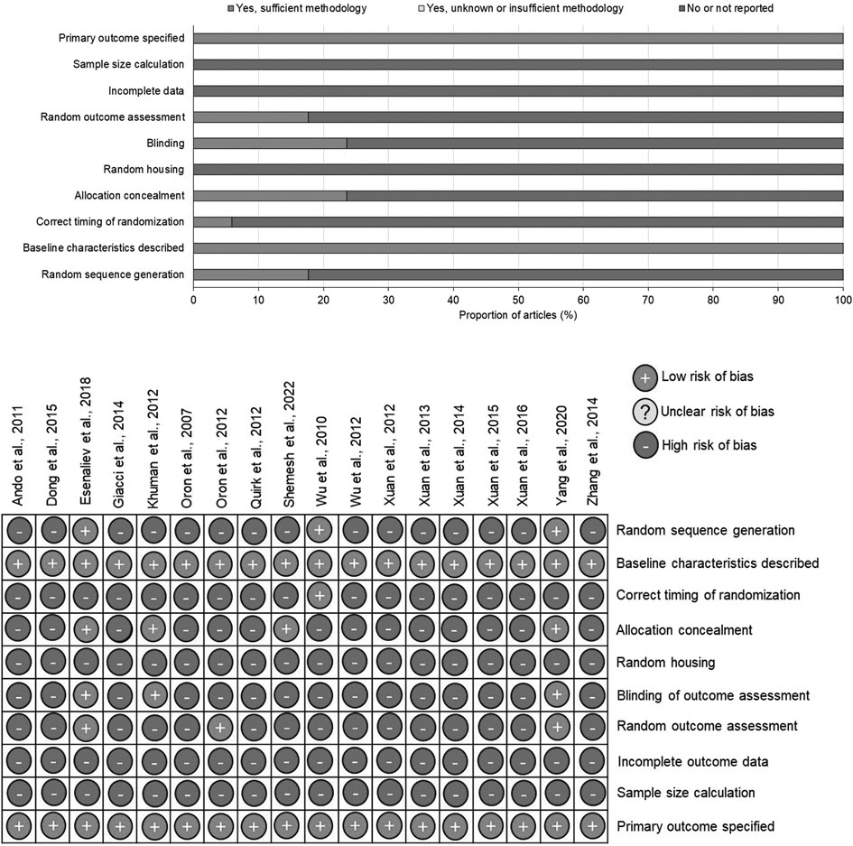

FIG. 4.

Risk of bias analysis for the included studies using the SYRCLE tool.

12

STEVENS ET AL.

considered. First, the time to initial dose is of great im-

portance: the therapeutic effect appears to be lost or

greatly diminished when ﬁrst dose administration is

models. Further, the beneﬁcial effects of PBM appear

to be lost where repeated administrations are given on a

daily basis over a number of days, although the optimum

duration of a treatment course cannot be established from

the current literature.

Xuan and associates (2013)<sup>41</sup>examined this directly

and showed that in their model the efﬁcacy increased

with 3 · versus 1 · doses, but any derived beneﬁt was

lost if the course continued to 14 · doses. While direct

comparative data are limited to this study, Yang and col-

leagues (2020) found considerable therapeutic beneﬁts,

particularly in functional outcomes, with doses given

over a 15-day course.

Establishing an optimum delivery technique

The speciﬁcs of delivery varied greatly between studies

using a transcranial delivery method. The PBM parame-

ters (irradiance, ﬂuence, and exposure time), positioning

factors (direct to skull, direct to scalp, or a speciﬁed dis-

tance from the scalp), and specimen factors (underlying

durotomy/craniotomy/closed surgical wound) all have

considerable effects on the dose delivery to the target

tissue.

The included results are not able to inform conclu-

sions regarding the potential beneﬁts of varying specif-

ics of a transcranial application method, nor inform

conclusions on the beneﬁts of either direct or trans-

cranial application of PBM. Only one study used both di-

rect and transcranial approaches (Khuman and coworkers

[2012]<sup>49</sup>), and they were not directly compared. Dosing

at 60 J/cm<sup>2</sup>60–80 min post-injury were concluded by

the authors as the main factors in eliciting functional im-

provements in MWM testing, with this dose performing

best in either direct or transcranial administration.

Administered directly, 60/120/210 J/cm<sup>2</sup>but not 30/

105 J/cm<sup>2</sup>, resulted in MWM hidden platform latency

improvements, and 60/120 J/cm<sup>2</sup>elicited probe trial

improvements.

Across all MWM outcomes, 60 J/cm<sup>2</sup>given at

60–80 min post-injury, whether delivered directly or

transcranially, were deemed to elicit similar modest im-

provements (although direct statistical comparison was

not presented). The remaining outcomes were not sig-

niﬁcantly improved by any PBM regimen tested in this

study.

While this review has principally considered the in-

cident energy exposure to injured target tissue (i.e., de-

livery to neural/glial cells), there is growing interest in

the systemic effects of PBM. Given the low penetrance

of R-NIR light to the brain from external application, it

has been hypothesized that transcranial PBM has con-

tributory effects from photon absorption in superﬁcial

tissues (scalp with its rich vascularity, skull with cal-

varial bone marrow).<sup>12,34,60</sup>The PBM directed to the

tibia in a mouse model of Alzheimer disease has

been shown to activate mesenchymal stem cells

(MSCs)<sup>61</sup>with neuroprotective effect. Calvarial bone

marrow niches have interfaces with CSF, which is a

possible conduit for activated MSCs from skull in

transcranial PBM.<sup>62</sup>

Further to this, PBM application to anatomically dis-

tant sites has been observed to result in therapeutic effects

in neurological disorders. Termed the ‘‘abscopal effect,’’

therapeutic action distant to irradiated tissue has been

recognized in radiotherapy since 1953<sup>63,64</sup>and more re-

cently considered in PBM.<sup>65</sup>Research in Parkinson dis-

ease has identiﬁed therapeutic beneﬁt for improvement

of clinical signs in a short series of patients receiving

PBM to the abdomen and neck,<sup>66</sup>with similar beneﬁts

to those observed with transcranial delivery.<sup>29</sup>

In animal models, however, direct stimulation appears

to carry greater beneﬁt.<sup>67,68</sup>The mechanism for this is

not known, but has been proposed as activation of remote

immune and stem cells that become systemically active

after PBM.<sup>67</sup>It is noteworthy here that the deep brain

target in Parkinson disease (substantia nigra) receives

signiﬁcantly attenuated doses in humans, even with trans-

cranial application.

Establishing the translational effect in humans

This review has focused on the acute phase of injury. The

applications of PBM in patients with TBI in clinical stud-

ies is, however, much more broad when considering

chronic or rehabilitative contexts and has been well sum-

marized elsewhere.<sup>30,54</sup>This systematic review identiﬁed

one study reporting the application of PBM in acute TBI

in human subjects. While the study was not sufﬁciently

powered to detect any functional beneﬁt, this study pro-

vides some evidence of a physiological effect of transcra-

nial PBM through radiological outcomes. Whether this

will translate to clinically relevant effects should be the

subject of further study, but Figuero Longo and col-

leagues<sup>69</sup>were able to demonstrate a favorable safety

proﬁle to support further study.

Similar to the presented pre-clinical literature, the

included clinical study raises issues with regard to mea-

surement and reporting of delivered dose. Data on ﬂuence

at a cortical level were not presented. Further, the total

number of doses received by enrolled patients varied

and was not transparently reported nor considered in

the data analysis. For this reason, the overall quality of

the study was deemed ‘‘fair,’’ and consideration for

dose, dose regimen, and dose delivery should be a key

consideration in the planning of further clinical trials of

PBM in TBI.

PHOTOBIOMODULATION IN ACUTE TBI

13

Establishing a mechanism

Through presentation of molecular substudies from the

included literature, this review has illustrated the broad

range of potential therapeutic mechanisms of PBM in

TBI. A full discussion of the complex and not fully elu-

cidated mechanism of PBM is beyond the scope of this

review; however, there are key themes observed from

the included articles.

In summary, PBM therapy in acute TBI appears to

correlate with: (1) increases in ATP levels<sup>38,39,46</sup>; (2)

reduction in reactive oxygen species<sup>39</sup>; (3) increase

in mitochondrial membrane potential<sup>39</sup>; (4) reduction

in microglial activation/astrogliosis<sup>45,47,49</sup>; (5) reduction

of proinﬂammatory mediators<sup>44</sup>; (6) reduction in apopto-

tic markers<sup>43,45,47,52</sup>; (7) decreased neuronal degenera-

tion<sup>41,45</sup>; (8) increased cell proliferation and maturation<sup>41,43</sup>;

and (9) increased cerebral blood ﬂow.<sup>53</sup>

Given the heterogeneity of PBM parameters and injury

models, it cannot be concluded whether such mechanisms

are speciﬁc to a particular PBM parameter/injury interac-

tion or representative of a broad mechanism of effect that

is common to PBM modalities in acute TBI. The pres-

ence of beneﬁcial effects on multiple discrete TBI patho-

physiological processes, however, is encouraging for its

prospective translational beneﬁt.

This systematic review has identiﬁed multiple studies

reporting reduction in neural degeneration in TBI after

PBM, reducing hippocampal (CA1) synaptic degrada-

tion,<sup>45</sup>and reducing degenerating neurons.<sup>41</sup>There is

also signiﬁcant evidence to support neurogenic and syn-

aptogenic activity stimulated by PBM.<sup>41,43,47</sup>Included

articles have identiﬁed increased subgranular cell prolif-

eration<sup>47</sup>; increased hippocampal, SVZ, and perilesional

cell proliferation<sup>41,43</sup>; and neuronal maturation and dif-

ferentiation of neuronal progenitor cells.<sup>43</sup>

Upregulation of BDNF post-PBM has been corre-

lated with increased expression of synapsin-1, with the

authors concluding that early BDNF upregulation may

mediate synaptogenesis in later (28 day post-injury) re-

covery phase.<sup>42</sup>In the wider literature, BDNF upregula-

tion has been observed in PBM treated animal models

of Alzheimer disease and has been proposed as a neuro-

protective mechanism for PBM.<sup>70</sup>Similarly, increased

neurogenesis<sup>71,72</sup>and synaptogenesis<sup>71</sup>have been ob-

served in occlusive and prothrombotic rat stroke models

after PBM treatment. Upregulation of BDNF expression

with PBM has also been demonstrated in an organotypic

hippocampal slice model<sup>73</sup>and a methanol-induced tox-

icity occipital cortex damage model.<sup>74</sup>

While the accumulated evidence presented here offers

insights into potential downstream pathways mediating

the therapeutic effects of PBM in acute TBI, understand-

ing of an overall mechanism of action for R/NIR light on

injured brain tissue remains incomplete. Integral to pho-

tobiological interaction, photons must be absorbed by a

biological molecule to elicit an effect—i.e., a chromo-

phore. CCO has been understood as a primary chromo-

phore of PBM,<sup>71,75,76</sup>with photon energy resulting in

the dissociation of nitric oxide,<sup>77</sup>increasing MMP and

ATP production, and modulating ROS production.<sup>74</sup>

While there is a clear role of the mitochondria in medi-

ating the biological effects of PBM, the speciﬁc role of

CCO has not been fully conﬁrmed.

A novel mechanism disparate to CCO has recently

emerged for 980 nm light: activating heat or light sensi-

tive calcium ion channels.<sup>78</sup>It remains possible, or even

likely, that there are further chromophores that contribute

to the wide-ranging biological effects of PBM, with dis-

crete and unidentiﬁed downstream mechanisms, with spe-

ciﬁc chromophores related to wavelength of PBM.

Risk of bias

The risk of bias across the included animal studies was

found to be generally high. In most cases, reporting of

factors as per SYRCLE guidelines was not adhered to.

All studies described baseline characteristics and had

clear primary outcomes; however, randomization and

blinding were overlooked by the majority of studies. To

ensure replicable and robust data to inform the ongoing

direction of PBM research in TBI, adherence to such

guidelines is strongly encouraged for future studies.

Controls

Included studies in this review have used control pro-

cedures that include the equivalent restraint required to

facilitate PBM, but without its application. It is arguable,

however, that this is an inadequate control: application of

a broadband light source at equivalent irradiance would

be a more robust approach. An ideal source would elicit

similar transient temperature changes to a PBM source to

control also for this secondary effect of PBM therapy and

would robustly identify that wavelength-speciﬁc doses of

incident light are the beneﬁcial factor.

A typical broadband source would deliver a fraction

of its energy in the form of wavelengths of therapeutic in-

terest. Such wavelengths could also be ﬁltered. If explor-

ing such options as controls, spectral irradiance should be

comprehensively measured and presented in the study

reporting.

PBM parameter reporting

The detail with which PBM parameters were employed

and reported in each study and substudy varied greatly.

Average irradiance and exposure time were reported

across studies, but reporting of results of cadaveric mod-

eling with direct measurement of transmitted PBM was

infrequent. No study presented data from computational

modeling of dose delivery or distribution. This enhances

difﬁculties in the between-study comparison of efﬁcacy:

14

STEVENS ET AL.

variability lies not only in PBM parameters but also in the

transmission of those parameters to the target tissue. This

is a salient and common shortcoming of much of the

PBM literature.<sup>79</sup>The accurate reporting of radiometry

in future studies should be prioritized.

Limitations

There are a number of limitations for this study. Because

of heterogeneity in the included studies’ selection of out-

come measure, the meta-analysis is not comprehensive in

scope and is able to represent only a subsection of the lit-

erature. Further, because of common outcome measure

preference within laboratories, high availability of NSS

data or lesion size data is inherently biased toward a se-

lective pool of publications.

A narrative review on PBM in TBI and stroke<sup>32</sup>from

the Hamblin laboratory presents an excellent summary

of the available data, with outputs categorized by re-

search group. Subgroup analyses were performed here

to maximize the value of meta-analysis by providing

some insight into the efﬁcacy of varying PBM parame-

ters. This, however, is not entirely robust given the in-

clusion of only a single study in some subgroups, and

conclusions should be guarded with that consideration.

Similarly, the statistical component of the meta-analysis

cannot account for the duplicate appearance of control

groups as though they were independent, where a single

control group is common across multiple substudies

where the data are taken from a single article.

As described above, PBM parameter reporting varied

in its quality, and in some instances the dose for PBM

parameters was calculated based on available beam trans-

mittance data and may not be entirely representative of

the ‘‘true’’ ﬁgure that was not directly measured in the

reported data.

This review does not comprise the available evidence

for applications of PBM in chronic TBI, although a re-

view summarizing these data is available in the litera-

ture.<sup>30</sup>The study of chronic TBI is predominantly in

case reports<sup>80–83</sup>or short case series<sup>84–86</sup>from human ap-

plications, in contrast to the evidence in acute TBI that is

predominantly in animal models. This is likely attribut-

able to the availability of replicable acute TBI models

in animals (in contrast to chronic TBI models), and the

practical logistics of patient recruitment in chronic (ver-

sus acute) TBI contexts. An ongoing randomized con-

trolled trial for patients with chronic TBI is likely to

provide more robust evidence on the efﬁcacy.<sup>87</sup>

In contrast, applications of PBM in patients with stroke

have predominantly been in the acute setting (NEST

studies<sup>33,88,89</sup>), and there is little quality evidence for

applications in the chronic rehabilitative phase post-

ischemic stroke.<sup>90</sup>While some comparisons between

pathologies (TBI, stroke) and time points (acute, chron-

ic) can be considered, the mechanisms, pathophysiol-

ogy, interventional goals, and outcome measures are

discrete and speciﬁc, supporting the focused nature of

this systematic review and meta-analysis.

Future directions

This study, in accordance with previous work,<sup>56</sup>has iden-

tiﬁed parameter heterogeneity and incomplete reporting

as factors that impede accurate conclusions to be taken

from PBM literature reviews. Accurate and comprehen-

sively reported radiometry should be prioritized in future

work for clearly established dose delivery to target tissue

to be compared between studies.<sup>79</sup>Given the lack of a

well-established therapeutic dose window in TBI, accu-

rate representation of dose delivery for comparison with

outcome measures is key to advancing this knowledge.

Transcranial approaches to PBM have a clear beneﬁt

in animal models, as illustrated here, but PBM delivery

via this route is inherently impeded by the thickness of

scalp and skull when translating this approach to humans.

Thorough clariﬁcation of the effective dose window will

be invaluable, alongside computational simulation, in

determining whether this approach is the optimal route

for clinical practice or whether more elaborate or novel

approaches

may

improve

delivery

and

functional

outcomes.<sup>91–96</sup>

Conclusion

This review has provided clear evidence of the beneﬁcial

effects of PBM in acute TBI. While speciﬁc parameters

for optimum effect cannot be determined, the literature

supports: wavelength selection in the regions of 665 or

810 nm; minimizing time to ﬁrst treatment; and lim-

ited total applications of daily PBM. Included studies

comprising mechanistic considerations support the hy-

potheses that PBM reduced cellular apoptosis, reduced

microglial activation and neuroinﬂammation, attenu-

ated neuronal degeneration, promoted neurogenesis/

synaptogenesis, and modulated metabolism.

Precise radiometry reporting in the literature for the

purposes of comparability between studies is encouraged

for future work. While clinical data in acute TBI are lim-

ited to a single study, a considered approach toward study

protocols should be taken to ensure that further clinical

study is utilizing optimal parameters and is conducted

to a high standard.

Authors’ Contributions

All authors have read and approved the full version

of this article. AS was responsible for conceptualization

and manuscript preparation. AS and ZA performed the

searches, risk of bias assessments, extracted the data

from the included articles, and performed the analysis.

All authors contributed to the development of the ideas/

writing/ﬁnal review of the submitted article.

PHOTOBIOMODULATION IN ACUTE TBI

15

Funding Information

This article presents independent research funded by the

National Institute for Health Research (NIHR) Surgical

Reconstruction and Microbiology Research Centre (part-

nership between University Hospitals Birmingham NHS

Foundation Trust, the University of Birmingham, and

the Royal Centre for Defence Medicine). The views

expressed are those of the author(s) and not necessar-

ily those of the NHS, the NIHR, or the Department of

Health.

Author Disclosure Statement

The research group has submitted a patent pending ap-

plication relating to the invasive delivery of PBM (UK

Patent Application No 2006201.4).

References

1. Maas AIR, Menon DK, David Adelson PD, et al. Traumatic brain injury:

integrated approaches to improve prevention, clinical care, and re-

search. Lancet Neurol 2017;16(12):987–1048; doi: 10.1016/S1474-

4422(17)30371-X.

2. Dewan M, Rattani A, Gupta S, et al. Estimating the global incidence

of traumatic brain injury. J Neurosurg 2018;130(4):1080–1097; doi:

10.3171/2017.10.JNS17352.

3. Ng SY, Lee AYW. Traumatic brain injuries: pathophysiology and potential

therapeutic targets. Front Cell Neurosci 2019;13:528; doi: 10.3389/

fncel.2019.00528.

4. Brain Trauma Foundation. Guidelines for the Management of Severe TBI,

4th ed. 2016. Available from: https://braintrauma.org/guidelines/

guidelines-for-the-management-of-severe-tbi-4th-ed#/ [Last

accessed: 8/26/2021].

5. Ahluwalia M, Kumar M, Ahluwalia P, et al. Rescuing mitochondria in

traumatic brain injury and intracerebral hemorrhages – a potential

therapeutic approach. Neurochem Int 2021;150:105192; doi: 10.1016/

j.neuint.2021.105192.

6. Simon DW, McGeachy MJ, Baylr H, et al. The far-reaching scope of

neuroinﬂammation after traumatic brain injury. Nat Rev Neurol

2017;13(3) 2017;13(3):171–191; doi: 10.1038/nrneurol.2017.13.

7. Chamoun R, Suki D, Gopinath SP, et al. Role of extracellular glutamate

measured by cerebral microdialysis in severe traumatic brain injury.

J Neurosurg 2010;113(3):564–570; doi: 10.3171/2009.12.JNS09689.

8. Khatri N, Thakur M, Pareek V, et al. Oxidative stress: major threat in

traumatic brain injury. CNS Neurol Disord Drug Targets

2018;17(9):689–695; doi: 10.2174/1871527317666180627120501.

9. Khellaf A, Khan DZ, Helmy A. Recent advances in traumatic brain injury.

J Neurol 2019;266:2878–2889; doi: 10.1007/s00415-019-09541-4.

10. Chung H, Dai T, Sharma SK, et al. The nuts and bolts of low-level laser

(light) therapy. Ann Biomed Eng 2012;40(2):516–533; doi: 10.1007/

s10439-011-0454-7.

11. Stepp H, Stummer W. 5-ALA in the management of malignant glioma.

Lasers Surg Med 2018;50(5):399–419; doi: 10.1002/lsm.22933.

12. Hamblin MR. Photobiomodulation for traumatic brain injury and stroke.

J Neurosci Res 2018;96(4):731–743; doi: 10.1002/jnr.24190.

13. de Freitas LF, Hamblin MR. Proposed mechanisms of photobiomodula-

tion or low-level light therapy. IEEE J Sel Top Quantum Electron

2016;22(3):7000417 doi: 10.1109/JSTQE.2016.2561201.

14. Dompe C, Moncrieff L, Matys J, et al. Photobiomodulation–underlying

mechanism and clinical applications. J Clin Med 2020;9(6):1724;

doi: http://dx.doi.org/10.3390/jcm9061724.

15. Yadav A, Gupta A. Noninvasive Red and near-infrared wavelength-

induced photobiomodulation: promoting impaired cutaneous wound

healing. Photodermatol Photoimmunol Photomed 2017;33(1):4–13;

doi: 10.1111/phpp.12282.

16. Yang WZ, Chen JY, Yu JT, et al. Effects of low power laser irradiation

on intracellular calcium and histamine release in RBL-2H3 mast cells.

Photochem Photobiol 2007;83(4):979–984; doi: 10.1111/j.1751-

1097.2007.00116.x.

17. Zhang P, Wu MX. A clinical review of phototherapy for psoriasis. Lasers

Med Sci 2018;33(1):173–180; doi: 10.1007/s10103-017-2360-1.

18. Ocon CA, Dos Santos SA, Caires JR, et al. Effects and parameters of the

photobiomodulation in experimental models of third-degree burn:

systematic review. Lasers Med Sci 2019;34(3):637–648; doi: 10.1007/

s10103-018-2633-3.

19. Baxter GD, Liu L, Petrich S, et al. Low level laser therapy (Photobiomo-

dulation therapy) for breast cancer-related lymphedema: a systematic

review. BMC Cancer 2017;17(1):833; doi: 10.1186/s12885-017-3852-x.

20. Cronshaw M, Parker S, Anagnostaki E, et al. Photobiomodulation and

oral mucositis: a systematic review. Dent J 2020;8(3): 87; doi: 10.3390/

dj8030087.

21. Ferroni C, Del Rio A, Martini C, et al. Light-induced therapies for pros-

tate cancer treatment. Front Chem 2019;7:719; doi: 10.3389/fchem

.2019.00719.

22. Zhou F, Yang J, Zhang Y, et al. Local phototherapy synergizes with

immunoadjuvant for treatment of pancreatic cancer through induced

immunogenic tumor vaccine. Clin Cancer Res 2018;24(21):5335-5346;

doi: 10.1158/1078-0432.CCR-18-1126.

23. Chung HH, Dai TH, Sharma SKS, et al. Editorial. Shapero BG, Mischoulon

D, and Cusin C. eds. Investig Ophthalmol Vis Sci 2019;9(1):57–62; doi:

24. Nishinaga Y, Sato K, Yasui H, et al. Targeted phototherapy for malignant

pleural mesothelioma: near-infrared photoimmunotherapy targeting

podoplanin. Cells 2020;9(4):1019; doi: 10.3390/cells9041019.

25. Ramezani F, Razmgir M, Tanha K, et al. Photobiomodulation for spinal

cord injury: a systematic review and meta-analysis. Physiol Behav

2020;224; doi: 10.1016/j.physbeh.2020.112977.

26. Hamblin M. Transcranial photobiomodulation for brain disorders. Biol

Psychiatry 2017;81(10 Suppl 1):S155; doi: 10.1016/j.biopsych.2017

.02.397.

27. Montazeri K, Farhadi M, Fekrazad R, et al. Transcranial photobiomodu-

lation in the management of brain disorders. J Photochem Photobiol B

2021;221:112207; doi: 10.1016/j.jphotobiol.2021.112207.

28. Moro C, El Massri N, Torres N, et al. Photobiomodulation inside the brain:

a novel method of applying near-infrared light intracranially and its

impact on dopaminergic cell survival in MPTP-treated mice.

J Neurosurg 2014;120(3):670–683; doi: 10.3171/2013.9.JNS13423.

29. Liebert A, Bicknell B, Laakso EL, et al. Improvements in clinical signs of

Parkinson’s disease using photobiomodulation: a prospective proof-

of-concept study. BMC Neurol 2021;21(1):256; doi: 10.1186/s12883-

021-02248-y.

30. Hamblin MR. Photobiomodulation for traumatic brain injury and stroke

(Vol 96, Pg 731, 2018). J Neurosci Res 2019;97(3):373; doi: 10.1002/

jnr.24376.

31. Figueiro Longo MG, Tan CO, Chan S-T, et al. Effect of transcranial low-

level light therapy vs sham therapy among patients with moderate

traumatic brain injury: a randomized clinical trial. JAMA Netw OPEN

2020;3(9):e2017337; doi: 10.1001/jamanetworkopen.2020.17337.

32. Hamblin MR. Photobiomodulation for traumatic brain injury and stroke.

J Neurosci Res 2018;96(4):731–743; doi: 10.1002/jnr.24190.

33. Acke W, Schellinger P, Albers G, et al. Transcranial laser therapy in acute

stroke treatment: results of neurothera effectiveness and safety trial 3,

a phase III clinical end point device trial. Stroke 2014;45(11):3187–

3193; doi: 10.1161/STROKEAHA.114.005795.

34. Hamblin MR. Shining light on the head: photobiomodulation for brain

disorders. BBA Clin 2016;6:113–124; doi: 10.1016/j.bbacli.2016.09.002.

35. Moher D, Liberati A, Tetzlaff J, et al. Preferred Reporting Items for

Systematic Reviews and Meta-Analyses: The PRISMA Statement. BMJ

2009;339(7716):332–336; doi: 10.1136/bmj.b2535.

36. Hooijmans CR, Rovers MM, De Vries RBM, et al. SYRCLE’s risk of bias

tool for animal studies. BMC Med Res Methodol 2014;14(1):1–9;

doi: 10.1186/1471-2288-14-43/TABLES/4.

37. Cochrane. Risk of Bias 2 (RoB 2) tool j Cochrane Methods. n.d.

Available from: https://methods.cochrane.org/risk-bias-2 [Last

accessed: 2/1/2022].

38. Ando T, Xuan WJ, Xu T, et al. Comparison of therapeutic effects between

pulsed and continuous wave 810-nm wavelength laser irradiation for

traumatic brain injury in mice. PLoS One 2011;6(10):26212; doi:

10.1371/journal.pone.0026212.

39. Dong T, Zhang Q, Hamblin MR, et al. Low-level light in combination with

metabolic modulators for effective therapy of injured brain. J Cereb

Blood Flow Metab 2015;35(9):1435–1444; doi: 10.1038/jcbfm.2015.87.

40. Wu QH, Xuan WJ, Ando T, et al. Low-level laser therapy for closed-head

traumatic brain injury in mice: effect of different wavelengths. Lasers

Surg Med 2012;44(3):218–226; doi: 10.1002/lsm.22003.

41. Xuan WJ, Vatansever F, Huang LY, et al. Transcranial low-level laser

therapy improves neurological performance in traumatic brain injury

16

STEVENS ET AL.

in mice: effect of treatment repetition regimen. Borlongan C V. ed.

PLoS One 2013;8(1):e53454; doi: 10.1371/journal.pone.0053454.

42. Xuan WJ, Agrawal T, Huang LY, et al. Low-level laser therapy for trau-

matic brain injury in mice increases brain derived neurotrophic factor

(BDNF) and synaptogenesis. J Biophotonics 2015;8(6):502–511; doi:

10.1002/jbio.201400069.

43. Xuan WJ, Vatansever F, Huang LY, et al. Transcranial low-level laser

therapy enhances learning, memory, and neuroprogenitor cells after

traumatic brain injury in mice. J Biomed Opt 2014;19(10); doi: 10.1117/

1.JBO.19.10.108003.

44. Xuan W, Huang L, Hamblin MR. Repeated transcranial low-level laser

therapy for traumatic brain injury in mice: biphasic dose response and

long-term treatment outcome. J Biophotonics 2016;9(11–12):1263–

1272; doi: 10.1002/jbio.201500336.

45. Yang B, Xu J, Li Y, et al. Photobiomodulation therapy for repeated closed

head injury in rats. J Biophotonics 2020;13(2):e201960117; doi:

10.1002/jbio.201960117.

46. Zhang Q, Zhou C, Hamblin MR, et al. Low-level laser therapy effectively

prevents secondary brain injury induced by immediate early respon-

sive gene X-1 deﬁciency. J Cereb Blood Flow Metab 2014;34(8):1391–

1401; doi: 10.1038/jcbfm.2014.95.

47. Esenaliev RO, Petrov IY, Petrov Y, et al. Nano-pulsed laser therapy is

neuroprotective in a rat model of blast-induced neurotrauma.

J Neurotrauma 2018;35(13):1510–1522; doi: 10.1089/neu.2017.5249.

48. Giacci MK, Wheeler L, Lovett S, et al. Differential effects of 670 and

830 nm red near infrared irradiation therapy: a comparative study of

optic nerve injury, retinal degeneration, traumatic brain and spinal

cord injury. PLoS One 2014;9(8):e104565; doi: 10.1371/journal.pone

.0104565.

49. Khuman J, Zhang J, Park J, et al. Low-level laser light therapy improves

cognitive deﬁcits and inhibits microglial activation after controlled

cortical impact in mice. J Neurotrauma 2012;29(2):408–417; doi:

10.1089/neu.2010.1745.

50. Oron A, Oron U, Streeter J, et al. Low-level laser therapy applied trans-

cranially to mice following traumatic brain injury signiﬁcantly reduces

long-term neurological deﬁcits. J Neurotrauma 2007;24(4):651–656;

doi: 10.1089/neu.2006.0198.

51. Oron A, Oron U, Streeter J, et al. Near infrared transcranial laser therapy

applied at various modes to mice following traumatic brain injury

signiﬁcantly reduces long-term neurological deﬁcits. J Neurotrauma

2012;29(2):401–407; doi: 10.1089/neu.2011.2062.

52. Quirk BJB, Torbey M, Buchmann E, et al. Near-infrared photobiomodu-

lation in an animal model of traumatic brain injury: improvements at

the behavioral and biochemical levels. Photomed Laser Surg 2012;

30(9):523–529; doi: 10.1089/pho.2012.3261.

53. Shemesh D, Aburus O, Turgeman G, et al. Quantiﬁcation of the ef-

fectivity of laser therapy shortly following brain injury via dual-

wavelength laser imaging. Opt Laser Technol 2022;145 (1):107506;

doi: 10.1016/j.optlastec.2021.107506.

54. Wu QH, Huang YY, Dhital S, et al. Low level laser therapy for traumatic

brain injury. Hamblin MR, Waynant RW, Anders J (eds). Mech low-light

Ther V 2010;7552(Conference on Mechanisms for Low-Light Therapy

V); doi: 10.1117/12.841014.

55. Bunce SC, Izzetoglu M, Izzetoglu K, et al. Functional near-infrared

spectroscopy. IEEE Eng Med Biol Mag 2006;25(4):54–62; doi: 10.1109/

memb.2006.1657788.

56. Zein R, Selting W, Hamblin MR. Review of light parameters and photo-

biomodulation efﬁcacy: dive into complexity. J Biomed Opt 2018;

23(12):1–17; doi: 10.1117/1.JBO.23.12.120901.

57. Huang YY, Chen ACH, Carroll JD, et al. Biphasic dose response in low

level light therapy. Dose-Response 2009;7(4):358–383; doi: 10.2203/

dose-response.09-027.Hamblin.

58. Huang YY, Sharma SK, Carroll J, et al. Biphasic dose response in low

level light therapy – an update. Dose Response 2011;9(4):602–618;

doi: 10.2203/dose-response.11-009.Hamblin.

59. Salehpour F, Cassano P, Rouhi N, et al. Penetration proﬁles of visible and

near-infrared lasers and light-emitting diode light through the head

tissues in animal and human species: a review of literature. Photo-

biomodul Photomed Laser Surg 2019;37(10):581–595; doi: 10.1089/

photob.2019.4676.

60. Salehpour F, Mahmoudi J, Kamari F, et al. Brain photobiomodulation

therapy: a narrative review. Mol Neurobiol 2018;55(8):6601–6636; doi:

10.1007/s12035-017-0852-4.

61. Farfara D, Tuby H, Trudler D, et al. Low-level laser therapy ameliorates

disease progression in a mouse model of Alzheimer’s disease. J Mol

Neurosci 2015;55(2):430–436; doi: 10.1007/S12031-014-0354-z.

62. Mazzitelli JA, Smyth LCD, Cross KA, et al. Cerebrospinal ﬂuid regulates

skull bone marrow niches via direct access through dural channels.

Nat Neurosci 2022;25(5):555–560; doi: 10.1038/s41593-022-01029-1.

63. Yilmaz MT, Elmali A, Yazici G. Abscopal effect, from myth to reality: from

radiation oncologists’ perspective. Cureus 2019;11(1):e3860; doi:

10.7759/cureus.3860.

64. Craig DJ, Nanavaty NS, Devanaboyina M, et al. The abscopal effect of

radiation therapy. Future Oncol 2021;17(13):1683–1694; doi: 10.2217/

fon-2020-0994

65. Johnstone DM, Mitrofanis J, Stone J. Targeting the body to protect the

brain: inducing neuroprotection with remotely-applied near infrared

light. Neural Regen Res 2015;10(3):349–351; doi: 10.4103/1673-

5374.153673.

66. Liebert A, Bicknell B, Laakso EL, et al. Remote photobiomodulation

treatment for the clinical signs of Parkinson’s disease: a case series

conducted during COVID-19. Photobiomodul Photomed Laser Surg

2022;40(2):112–122; doi: 10.1089/photob.2021.0056.

67. Johnstone DM, Hamilton C, Gordon LC, et al. Exploring the use of in-

tracranial and extracranial (remote) photobiomodulation devices in

Parkinson’s disease: a comparison of direct and indirect systemic

stimulations. J Alzheimers Dis 2021;83(4):1399–1413; doi: 10.3233/

JAD-210052.

68. Johnstone DM, El Massri N, Moro C, et al. Indirect application of near

infrared light induces neuroprotection in a mouse model of parkin-

sonism - an abscopal neuroprotective effect. Neuroscience

2014;274:93–101; doi: 10.1016/j.neuroscience.2014.05.023.

69. Figueiro Longo MG, Tan CO, Chan ST, et al. Effect of transcranial

low-level light therapy vs sham therapy among patients with mod-

erate traumatic brain injury: a randomized clinical trial. JAMA Netw

Open 2020;3(9):e2017337; doi: 10.1001/jamanetworkopen.2020

.17337.

70. Meng C, He Z, Xing D. Low-level laser therapy rescues dendrite atrophy

via upregulating BDNF expression: implications for Alzheimer’s dis-

ease. J Neurosci 2013;33(33):13505–13517; doi: 10.1523/JNEUROSCI

.0918-13.2013.

71. Yang LD, Tucker D, Dong Y, et al. Photobiomodulation therapy promotes

neurogenesis by improving post-stroke local microenvironment and

stimulating neuroprogenitor cells. Exp Neurol 2018;299(Pt A):86–96;

doi: 10.1016/j.expneurol.2017.10.013.

72. Oron A, Oron U, Chen J, et al. Low-level laser therapy applied transcra-

nially to rats after induction of stroke signiﬁcantly reduces long-term

neurological deﬁcits. Stroke 2006;37(10):2620–2624; doi: 10.1161/

01.STR.0000242775/14642/b8.

73. Ghanbari A, Ghareghani M, Delaviz H, et al. Light-emitting diode (LED)

therapy improves occipital cortex damage by decreasing apoptosis

and increasing BDNF-expressing cells in methanol-induced toxicity in

rats. Biomed Pharmacother 2017;89:1320–1330; doi: 10.1016/j.biopha

.2017.03.024.

74. Heo JC, Park JA, Kim DK, et al. Photobiomodulation (660 Nm) therapy

reduces oxidative stress and induces BDNF expression in the hippo-

campus. Sci Rep 2019;9(1):10114; doi: 10.1038/s41598-019-46490-4.

75. Karu TI. Multiple roles of cytochrome c oxidase in mammalian cells

under action of red and IR-A radiation. IUBMB Life 2010;62(8):607–610;

doi: 10.1002/iub.359.

76. Karu TI. Molecular mechanism of the therapeutic effect of low-intensity

laser radiation. Lasers Life Sci 1988;2(1):53–74.

77. Hamblin MR. The role of nitric oxide in low level light therapy. Mech

Low-Light Ther III 2008;6846:684602; doi: 10.1117/12.764918.

78. Wang Y, Huang YY, Wang Y, et al. Photobiomodulation of human

adipose-derived stem cells using 810nm and 980nm lasers operates

via different mechanisms of action. Biochim Biophys Acta Gen Subj

2017;1861(2):441–449; doi: 10.1016/j.bbagen.2016.10.008.

79. Hadis MA, Zainal SA, Holder MJ, et al. The dark art of light measurement:

accurate radiometry for low-level light therapy. Lasers Med Sci 2016;

31(4):789–809; doi: 10.1007/s10103-016-1914-y.

80. Naeser MA, Saltmarche A, Krengel MH, et al. Improved cognitive func-

tion after transcranial, light-emitting diode treatments in chronic,

traumatic brain injury: two case reports. Photomed Laser Surg

2011;29(5):351–358; doi: 10.1089/pho.2010.2814.

81. Bogdanova Y, Ho V, Martin P, et al. Transcranial LED treatment for

cognitive dysfunction and sleep in chronic TBI: randomized controlled

pilot trial. Arch Phys Med Rehabil 2017;98(10):e122–e123; doi:

10.1016/J.APMR.2017.08.398.

82. Henderson TA, Morries LD. SPECT perfusion imaging demonstrates im-

provement of traumatic brain injury with transcranial near-infrared

laser phototherapy. Adv Mind Body Med 2015;29(4):27–33.

PHOTOBIOMODULATION IN ACUTE TBI

17

83. Nawashiro H, Wada K, Nakai K, et al. Focal increase in cerebral blood ﬂow

after treatment with near-infrared light to the forehead in a patient in

a persistent vegetative state. Photomed Laser Surg 2012;30(4):231–

233; doi: 10.1089/pho.2011.3044.

84. Naeser MA, Zafonte R, Krengel MH, et al. Signiﬁcant improvements in

cognitive performance post-transcranial, red/near-infrared light-

emitting diode treatments in chronic, mild traumatic brain injury:

open-protocol study. J Neurotrauma 2014;31(11):1008–1017; doi:

10.1089/neu.2013.3244.

85. Naeser MA, Martin PI, Ho MD, et al. Transcranial, red/near-infrared light-

emitting diode therapy to improve cognition in chronic traumatic

brain injury. Photomed Laser Surg 2016;34(12):610–626; doi: 10.1089/

pho.2015.4037.

86. Morries LD, Cassano P, Henderson TA. Treatments for traumatic brain

injury with emphasis on transcranial near-infrared laser phototherapy.

Neuropsychiatr Dis Treat 2015;11:2159–2175; doi: 10.2147/NDT

.S65809.

87. Poiani GDR, Zaninotto AL, Carneiro AMC, et al. Photobiomodulation

using low-level laser therapy (LLLT) for patients with chronic traumatic

brain injury: a randomized controlled trial study protocol. Trials

2018;19; doi: 10.1186/s13063-017-2414-5.

88. Lampl Y, Zivin JA, Fisher M, et al. Infrared laser therapy for ischemic

stroke: a new treatment strategy: results of the NeuroThera Effec-

tiveness and Safety Trial-1 (NEST-1). Stroke 2007;38(6):1843–1849;

doi: 10.1161/STROKEAHA.106.478230.

89. Huisa BN, Stemer AB, Walker MG, et al. Transcranial laser therapy

for acute ischemic stroke: a pooled analysis of NEST-1 and NEST-2.

Int J Stroke 2013;8(5):315–320; doi: 10.1111/j.1747-4949.2011

.00754.x.

90. Naeser MA, Ho MD, Martin PI, et al. Increased functional connectiv-

ity within intrinsic neural networks in chronic stroke following treat-

ment with red/near-infrared transcranial photobiomodulation:

case series with improved naming in aphasia. Photobiomodul

Photomed Laser Surg 2020;38(2):115–131; doi: 10.1089/photob.2019

.4630.

91. Pitzschke A, Lovisa B, Seydoux O, et al. Red and NIR Light dosimetry

in the human deep brain. Phys Med Biol 2015;60(7):2921–2937;

doi: 10.1088/0031-9155/60/7/2921.

92. Darlot F, Moro C, El Massri N, et al. Near-Infrared light is neuroprotective

in a monkey model of Parkinson disease. Ann Neurol 2016;79(1):59–

75; doi: 10.1002/ana.24542.

93. Hart NS, Fitzgerald M. A new perspective on delivery of red-near-infrared

light therapy for disorders of the brain. Discov Med 2016;22(120):147–

156; doi: 10.1161/01.STR.0000242775.14642.b8.

94. Liu Y, Lai P, Ma C, et al. Optical focusing deep inside dynamic scattering

media with near-infrared time-reversed ultrasonically encoded (TRUE)

light. Nat Commun 2015;6:5904; doi: 10.1038/ncomms6904.

95. Scopelliti MG, Chamanzar M. Ultrasonically sculpted virtual relay lens for

in situ microimaging. Light Sci Appl 2019;8(1); doi: 10.1038/S41377-

019-0173-7.

96. Sagar V, Atluri VSR, Tomitaka A, et al. Coupling of transient near infrared

photonic with magnetic nanoparticle for potential dissipation-free

biomedical application in brain. Sci Rep 2016;6:29792; doi: 10.1038/

srep29792.

18

STEVENS ET AL.